# An Introduction to the **'animalmove'** package

## Introduction

The **animalmove** package provides a series statistical analyses of the spatio-temporal animal movement patterns at the population level. The package implement analyses described in the original paper **“How landscape dynamics link individualto population-level movement patterns:a multispecies comparison of ungulate relocation data”** (Mueller T., et. al, 2011).

## Statistical Analyses

There are three statistical analyses in the package:

- Realized Mobility Index
- Movement Coordination Index
- Population Dispersion Index

Each of the analyses incorporates the methodology described in the paper, and produces a numerical outcome, which can assesed by the examining the result set or summarized and visualized the custom summaries and high-level functions.

The analyses assume the relocation data of multiple species are preliminary syncronized and preprocessed by time and space dimensions.

We start with the import of the library **animalmove** in R environment. The package can be installed in the local system from the source package archive for OS X or Win platform.

## Package installation

```r
# Optionally install devtool package install.packages('devtools')
library(devtools)
# install_local('path_to_the_package_archive')

# MAC OS install_local('/path/animalmove_0.1.0.99.tar.gz')

# Win install_local('/path/animalmove_0.1.0.99.zip')

# Load library
library(animalmove)
```

## Data Import

The data can be imported in R using conventional form of reading data from csv/text files, and transforming them in *Individuals* object data frame.

```r
# Read data the sample data set is located in misc directory of the source
# archive.

caribou <- read.csv("/apps/git/animalmove/misc/originaldata/16_day_5_individuals_data_Caribou.csv")
gazelle <- read.csv("/apps/git/animalmove/misc/originaldata/16_day_5_individuals_data_Gazelle.csv")
moose <- read.csv("/apps/git/animalmove/misc/originaldata/16_day_5_individuals_data_Moose.csv")
guanaco <- read.csv("/apps/git/animalmove/misc/originaldata/16_day_5_individuals_data_Gaunaco.csv")
```

```r
# Load Data

# Caribou data

# Copy caribou data to the data table
dt.caribou <- data.table(caribou)

# Create attribute data frame
dt.caribou.attr <- dt.caribou[, list(id = uniqueID, pop.type = "caribou", x = xAlaskaAlb *
    1000, y = caribou$yAlaskaAlb * 1000, time.lag = daysToFind)]

# Gazelle data

# Copy gazelle data to the data table
dt.gazelle <- data.table(gazelle)

# Create attribute data frame
dt.gazelle.attr <- dt.gazelle[, list(id = id, pop.type = "gazelle", x = xm *
    1000, y = ym * 1000, time.lag = daysToFind)]

# Load Moose data

# Copy moose data to the data table
dt.moose <- data.table(moose)

# Create attribute data frame
dt.moose.attr <- dt.moose[, list(id = uniqueID, pop.type = "moose", x = xm *
    1000, y = ym * 1000, time.lag = daysToFind)]

# Load guanaco data

# Copy guanaco data to the data table
dt.guanaco <- data.table(guanaco)


# Create attribute data frame
dt.guanaco.attr <- dt.guanaco[, list(id = uniqueID, pop.type = "guanaco", x = xm *
    1000, y = ym * 1000, time.lag = daysToFind)]
allpopulations <- rbind(dt.caribou.attr, dt.gazelle.attr, dt.moose.attr, dt.guanaco.attr)

# save data

# save(allpopulations, file='/apps/git/animalmove/data/allpopulations.rda')

# Create spatial coordinates

dt.allpopulations <- data.table(allpopulations)

dt.allpopulations.xy <- dt.allpopulations[, list(x, y)]

str(dt.allpopulations.xy)
```

```
## Classes 'data.table' and 'data.frame':   310 obs. of  2 variables:
##  $ x: num  620673 597224 575563 411808 372566 ...
##  $ y: num  2188198 2173363 2179598 2193228 2190453 ...
##  - attr(*, ".internal.selfref")=<externalptr>
```

```r
dt.allpopulations.attr <- dt.allpopulations[, list(id, pop.type, time.lag)]

# Create spatial points
xy.sp.allpopulations <- SpatialPoints(dt.allpopulations.xy)

# Create spatial points data frame with attributes
xy.allpopulations.spdf <- SpatialPointsDataFrame(xy.sp.allpopulations, dt.allpopulations.attr)
str(xy.allpopulations.spdf)
```

```
## Formal class 'SpatialPointsDataFrame' [package "sp"] with 5 slots
##   ..@ data       :'data.frame':  310 obs. of  3 variables:
##   .. ..$ id      : Factor w/ 20 levels "583657","601607",..: 13 13 13 13 13 13 13 13 13 13 ...
##   .. ..$ pop.type: chr [1:310] "caribou" "caribou" "caribou" "caribou" ...
##   .. ..$ time.lag: int [1:310] 105 121 137 153 169 185 201 217 233 249 ...
##   ..@ coords.nrs : num(0)
##   ..@ coords     : num [1:310, 1:2] 620673 597224 575563 411808 372566 ...
##   .. ..- attr(*, "dimnames")=List of 2
##   .. .. ..$ : NULL
##   .. .. ..$ : chr [1:2] "x" "y"
##   ..@ bbox       : num [1:2, 1:2] -820509 -511436 1821501 2242778
##   .. ..- attr(*, "dimnames")=List of 2
##   .. .. ..$ : chr [1:2] "x" "y"
##   .. .. ..$ : chr [1:2] "min" "max"
##   ..@ proj4string:Formal class 'CRS' [package "sp"] with 1 slots
##   .. .. ..@ projargs: chr NA
```

```r
# Create Individuals data.frame - relocations of gazelle data
allpopulations.spatial <- Individuals(xy.allpopulations.spdf, group.by = "pop.type")

# save(allpopulations.spatial,
# file='/apps/git/animalmove/data/allpopulations.spatial.rda')

# End Load Data
```

## Realized Mobility Index

```r
# Realized Mobility Index
data(allpopulations.spatial)

# compute individual mcp
individual.mcp <- mcp(allpopulations.spatial[, 1], percent = 100)

# display mcp
individual.mcp
```

```
## Object of class "SpatialPolygonsDataFrame" (package sp):
##
## Number of SpatialPolygons:  20
##
## Variables measured:
##            id    area
## 583657 583657 2780300
## 601607 601607  631006
## 602189 602189 2208462
## 602190 602190  723942
## 602191 602191  825206
## F6         F6    2796
## ...
```

```r
# compute population mcp
population.mcp <- mcp.population(allpopulations.spatial, percent = 100)

# display mcp
population.mcp
```

```
## Object of class "SpatialPolygonsDataFrame" (package sp):
##
## Number of SpatialPolygons:  4
##
## Variables measured:
##              id     area
## caribou caribou 10768516
## gazelle gazelle  4477248
## guanaco guanaco   162400
## moose     moose    28201
```

```r
# compute RMIndex object that is a data.frame

rmi.index.pop <- rmi.index(allpopulations.spatial, percent = 100, id = "id")
rmi.object <- RMIndex(rmi.index.pop)

# RMI Data
rmi.object@data
```

```
##          id pop.type ind.home.range pop.home.range rmi.index
## 1    583657  gazelle        2780300        4477248   0.62098
## 2    601607  gazelle         631006        4477248   0.14094
## 3    602189  gazelle        2208462        4477248   0.49326
## 4    602190  gazelle         723942        4477248   0.16169
## 5    602191  gazelle         825206        4477248   0.18431
## 6        F6    moose           2796          28201   0.09914
## 7   Iris474  guanaco          92608         162400   0.57025
## 8        M4    moose           1794          28201   0.06362
## 9        M6    moose           5416          28201   0.19207
## 10       M7    moose           1285          28201   0.04558
## 11       M8    moose           2129          28201   0.07550
## 12  Name213  guanaco          60964         162400   0.37539
## 13  S435891  caribou        5511582       10768516   0.51182
## 14  S515876  caribou        7507306       10768516   0.69715
## 15  S587873  caribou        5115407       10768516   0.47503
## 16  S597881  caribou        7225956       10768516   0.67103
## 17  S617880  caribou        8555763       10768516   0.79452
## 18  caro514  guanaco          49301         162400   0.30358
## 19 pablo097  guanaco           8118         162400   0.04999
## 20    su394  guanaco          12238         162400   0.07536
```

```r
summary(rmi.object)
```

```
## $caribou
##    Min. 1st Qu.  Median    Mean 3rd Qu.    Max.
##   0.475   0.512   0.671   0.630   0.697   0.795
##
## $gazelle
##    Min. 1st Qu.  Median    Mean 3rd Qu.    Max.
##   0.141   0.162   0.184   0.320   0.493   0.621
##
## $guanaco
##    Min. 1st Qu.  Median    Mean 3rd Qu.    Max.
##  0.0500  0.0754  0.3040  0.2750  0.3750  0.5700
##
## $moose
##    Min. 1st Qu.  Median    Mean 3rd Qu.    Max.
##  0.0456  0.0636  0.0755  0.0952  0.0991  0.1920
```

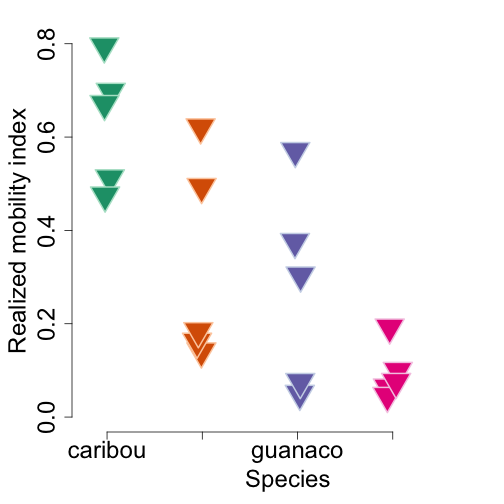

```r
par(mar = c(5, 5, 2, 0))
plot(rmi.object)
```

```r
# End Realized Mobility Index
```

## Movement Coordination Index

```r
ind.ds <- puechabonsp
```

[output not shown]

```r
ind.reloc <- ind.ds$relocs
```

[output not shown]

```r
ind.reloc@data$type <- "type1"
```

[output not shown]

```r
ind.reloc@data[1:50, 5] <- "type2"
```

[output not shown]

```r
head(ind.reloc, 53)
```

[output not shown]

```r
pop.data <- Individuals(ind.reloc, group.by = c("type"))
```

[output not shown]

```r
pop.data@data$time.lag <- 365
```

[output not shown]

```r
pop.data@data[1:50, 6] <- 200
```

[output not shown]

```r
# display data population data
str(pop.data)
```

[output not shown]

```r
pop.data
```

[output not shown]

```r
group.by = colnames(populations(pop.data))
```

[output not shown]

```r
index.group.by = grep(group.by, colnames(pop.data@data))
```

[output not shown]

```r
# test - call using generic method
res.ind <- mci.index(pop.data, group.by = c("type"), time.lag = c("time.lag"))
```

[output not shown]

```r
# display data
head(res.ind)
```

[output not shown]

```r
# Create MCIndex object
mci.object <- MCIndex(res.ind)
```

[output not shown]

```r
mci.object
```

[output not shown]

```r
# Compute ANOVA stats

anova.model <- aov(mci.object)
```

[output not shown]

```r
# display anova
anova.model
```

[output not shown]

```r
# TukeyHSD from model
TukeyHSD(anova.model)
```

[output not shown]

## Population Dispersion Index

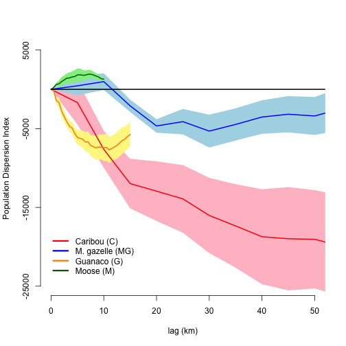

```r
# Population Dispersion Index

# load data
data(caribou.reloc.16day.5indiv)
data(gazelle.reloc.16day.5indiv)
data(moose.reloc.16day.5indiv)
data(guanaco.reloc.16day.5indiv)

caribou.scale = seq(0, 1e+05, 5000)  #caribou and gazelles
gazelle.scale = caribou.scale
moose.scale = seq(0, 10000, 500)  #moose
guanaco.scale = seq(0, 15000, 500)  #guanaco


# create PDIndex for each specie
pdi.index.caribou <- pdi.index(caribou.reloc.16day.5indiv, percent = 100, caribou.scale,
    unin = "m", unout = "km2")
pdi.index.gazelle <- pdi.index(gazelle.reloc.16day.5indiv, percent = 100, gazelle.scale,
    unin = "m", unout = "km2")
pdi.index.guanaco <- pdi.index(guanaco.reloc.16day.5indiv, percent = 100, guanaco.scale,
    unin = "m", unout = "km2")
pdi.index.moose <- pdi.index(moose.reloc.16day.5indiv, percent = 100, moose.scale,
    unin = "m", unout = "km2")

# Get summaries of each specie PDI

summary.caribou <- summary.pdi(pdi.index.caribou)
summary.gazelle <- summary.pdi(pdi.index.gazelle)
summary.guanaco <- summary.pdi(pdi.index.guanaco)
summary.moose <- summary.pdi(pdi.index.moose)

# Create X and Y axes for each species

# caribou
caribou.X <- c(summary.caribou$scale, rev(summary.caribou$scale))
caribou.Y <- c(summary.caribou$mean.pdi + summary.caribou$se.pdi, rev(summary.caribou$mean.pdi -
    summary.caribou$se.pdi))

# gazelle
gazelle.X <- c(summary.gazelle$scale, rev(summary.gazelle$scale))
gazelle.Y <- c(summary.gazelle$mean.pdi + summary.gazelle$se.pdi, rev(summary.gazelle$mean.pdi -
    summary.gazelle$se.pdi))

# guanaco
guanaco.X <- c(summary.guanaco$scale, rev(summary.guanaco$scale))
guanaco.Y <- c(summary.guanaco$mean.pdi + summary.guanaco$se.pdi, rev(summary.guanaco$mean.pdi -
    summary.guanaco$se.pdi))

# moose
moose.X <- c(summary.moose$scale, rev(summary.moose$scale))
moose.Y <- c(summary.moose$mean.pdi + summary.moose$se.pdi, rev(summary.moose$mean.pdi -
    summary.moose$se.pdi))


# Plot default settings

colorCaribou = "pink"
colorGazelle = "lightblue"
colorGuanaco = "khaki1"  #'#FFFF99'
colorMoose = "lightgreen"
colorCaribou2 = "red"
colorGazelle2 = "blue"
colorGuanaco2 = "darkorange"
colorMoose2 = "darkgreen"

cexValue = 2

cexValue = 1

# Change number of panels in the plotting window back to a single panel
par(mfrow = c(1, 1))

# Change margin size par(mar = c(5, 5, 2, 1))

# Create empty plot, with axes labels
plot(caribou.scale, summary.gazelle$mean.pdi, ylim = c(-25000, 5000), xlim = c(0,
    50000), col = NA, ylab = "Population Dispersion Index", xlab = "lag (km)",
    cex.lab = cexValue, cex.axis = cexValue, cex = cexValue, axes = F)

# Add caribou data
polygon(caribou.X, caribou.Y, col = colorCaribou, border = NA)  # plots CI's

# Add gazelle data
polygon(gazelle.X, gazelle.Y, col = colorGazelle, border = NA)  # plots CI's

# Add Moose data
polygon(moose.X, moose.Y, col = colorMoose, border = NA)  # plots CI's

# Add guanaco data
polygon(guanaco.X, guanaco.Y, col = colorGuanaco, border = NA)  # plots CI's


# Add lines
lines(summary.caribou$scale, summary.caribou$mean.pdi, col = colorCaribou2,
    lwd = 2)  # plots PDI
lines(summary.gazelle$scale, summary.gazelle$mean.pdi, col = colorGazelle2,
    lwd = 2)  # plots PDI
lines(summary.moose$scale, summary.moose$mean.pdi, col = colorMoose2, lwd = 2)  # plots PDI
lines(summary.guanaco$scale, summary.guanaco$mean.pdi, col = colorGuanaco2,
    lwd = 2)  # plots PDI


lines(c(0, 1e+05), c(0, 0), lwd = 2, lty = 1)  # add baseline

# Add axes
axis(1, at = seq(0, 50000, 10000), labels = seq(0, 50, 10), cex.axis = cexValue)
axis(2, at = seq(-25000, 5000, 10000), cex.axis = cexValue)

# Add legend
legend(-1000, -18000, legend = c("Caribou (C)", "M. gazelle (MG)", "Guanaco (G)",
    "Moose (M)"), col = c(colorCaribou2, colorGazelle2, colorGuanaco2, colorMoose2),
    box.lty = 0, lty = 1, lwd = 3, cex = cexValue, bg = NA)
```

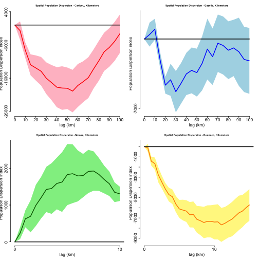

```r
par(mfrow = c(2, 2))
par(cex = 0.35)
plot(pdi.index.caribou, col = colorCaribou, linecol = colorCaribou2, title = "Spatial Population Dispersion - Caribou, Kilometers")
plot(pdi.index.gazelle, col = colorGazelle, linecol = colorGazelle2, title = "Spatial Population Dispersion - Gazelle, Kilometers")
plot(pdi.index.moose, col = colorMoose, linecol = colorMoose2, title = "Spatial Population Dispersion - Moose, Kilometers")
plot(pdi.index.guanaco, col = colorGuanaco, linecol = colorGuanaco2, title = "Spatial Population Dispersion - Guanaco, Kilometers")
```